# Comprehensive Analysis

Data Analysis Team

2025-12-15

```r
library(sjmisc)
library(ResourceSelection)
```

```
## ResourceSelection 0.3-6   2023-06-27
```

```r
library(pROC)
library(broom)
library(dplyr)
library(kableExtra)
library(lavaan)
```

```r
library(ggplot2)
library(gridExtra)
library(reshape2)
library(psych)
library(MVN)
library(openxlsx)
library(summarytools)
library(corrplot)
library(ggpubr)
library(car)
library(rstatix)
library(boot)
library(tidyr)
```

# 1. Introduction

This comprehensive analysis examines factors influencing academic performance, measured by GPA and ClassGPA. The analysis includes exploratory data analysis, exploratory factor analysis, demographic comparisons, structural equation modeling, and comprehensive assumption checks.

# 2. Data Preparation

```r
# Load the dataset
data <- read.xlsx("finalDataset.xlsx")

# Display basic information about the dataset
cat("Dataset dimensions:", dim(data), "\n")
```

```
## Dataset dimensions: 166 21
```

```r
cat("Variables in dataset:", names(data), "\n\n")
```

```
## Variables in dataset: Year Program Gender GPA ClassGPA Academic_screen_time NonAcademic_screen_time Studytime_phone_check_frequency Studytime_notification_distraction Independent_learning_hours Daytime_sleepiness Night_sleep_hours Sleep_disturbance Subjective_sleep_quality Sleep_onset_latency Nom…
```

```r
# Create a summary of all variables
df_summary <- dfSummary(data)
print(df_summary)
```

```
## Data Frame Summary
## data
## Dimensions: 166 x 21
## Duplicates: 0
##
## ----------------------------------------------------------------------------------------------------------------------------------
## No   Variable                             Stats / Values            Freqs (% of Valid)    Graph               Valid      Missing
## ---- ------------------------------------ ------------------------- --------------------- ------------------- ---------- ---------
## 1    Year                                 1. Level_2                84 (50.6%)            IIIIIIIIII          166        0
##      [character]                          2. Level_3                82 (49.4%)            IIIIIIIII           (100.0%)   (0.0%)
##
## 2    Program                              1. BS                     37 (22.3%)            IIII                166        0
##      [character]                          2. CS                     29 (17.5%)            III                 (100.0%)   (0.0%)
##                                           3. FMIS                   41 (24.7%)            IIII
##                                           4. PS                     59 (35.5%)            IIIIIII
##
## 3    Gender                               1. Female                 86 (51.8%)            IIIIIIIIII          166        0
##      [character]                          2. Male                   80 (48.2%)            IIIIIIIII           (100.0%)   (0.0%)
##
## 4    GPA                                  Mean (sd) : 2.9 (0.6)     112 distinct values             : .       166        0
##      [numeric]                            min < med < max:                                          : :       (100.0%)   (0.0%)
##                                           0.4 < 3 < 3.9                                             : : .
##                                           IQR (CV) : 0.7 (0.2)                                    : : : :
##                                                                                                 . : : : :
##
## 5    ClassGPA                             1. No                     85 (51.2%)            IIIIIIIIII          166        0
##      [character]                          2. Yes                    81 (48.8%)            IIIIIIIII           (100.0%)   (0.0%)
##
## 6    Academic_screen_time                 Mean (sd) : 1.6 (1.1)     0 : 28 (16.9%)        III                 166        0
##      [numeric]                            min < med < max:          1 : 54 (32.5%)        IIIIII              (100.0%)   (0.0%)
##                                           0 < 2 < 4                 2 : 56 (33.7%)        IIIIII
##                                           IQR (CV) : 1 (0.7)        3 : 19 (11.4%)        II
##                                                                     4 :  9 ( 5.4%)        I
##
## 7    NonAcademic_screen_time              Mean (sd) : 2.5 (0.9)     0 :  1 ( 0.6%)                            166        0
##      [numeric]                            min < med < max:          1 : 21 (12.7%)        II                  (100.0%)   (0.0%)
##                                           0 < 2 < 4                 2 : 64 (38.6%)        IIIIIII
##                                           IQR (CV) : 1 (0.4)        3 : 54 (32.5%)        IIIIII
##                                                                     4 : 26 (15.7%)        III
##
```

[output cut: 75 more lines]

```
##                                           IQR (CV) : 1 (0.6)        3 : 20 (12.0%)        II
##                                                                     4 :  7 ( 4.2%)
##
## 20   Nomophobia5                          Mean (sd) : 2 (1.1)       0 : 14 ( 8.4%)        I                   166        0
##      [numeric]                            min < med < max:          1 : 45 (27.1%)        IIIII               (100.0%)   (0.0%)
##                                           0 < 2 < 4                 2 : 56 (33.7%)        IIIIII
##                                           IQR (CV) : 2 (0.6)        3 : 34 (20.5%)        IIII
##                                                                     4 : 17 (10.2%)        II
##
## 21   Screen_time                          Mean (sd) : 5.4 (2.1)     125 distinct values           :           166        0
##      [numeric]                            min < med < max:                                    . : :           (100.0%)   (0.0%)
##                                           0.8 < 5.3 < 12.4                                    : : : .
##                                           IQR (CV) : 2.5 (0.4)                              : : : : :
##                                                                                           : : : : : : : : .
## ----------------------------------------------------------------------------------------------------------------------------------
```

```r
# Separate demographic and academic variables
demographic_data <- data[, c("Year", "Program", "Gender", "GPA", "ClassGPA")]
efa_data <- data[, !(names(data) %in% c("Year", "Program", "Gender", "GPA", "ClassGPA"))]

# Handle missing values
if(any(is.na(efa_data))) {
  efa_data <- as.data.frame(lapply(efa_data, function(x) {
    if(any(is.na(x))) {
      x[is.na(x)] <- mean(x, na.rm = TRUE)
    }
    x
  }))
  cat("Missing values imputed with column means\n")
}

# Remove variables with zero or near-zero variance
variances <- apply(efa_data, 2, var)
low_var <- which(variances < 0.01)
if(length(low_var) > 0) {
  efa_data <- efa_data[, -low_var]
  cat("Removed", length(low_var), "variables with near-zero variance\n")
}

cat("Final EFA dataset dimensions:", dim(efa_data), "\n")
```

```
## Final EFA dataset dimensions: 166 16
```

# 3. Exploratory Data Analysis

## 3.1. Descriptive Statistics

```r
# Summary statistics for all variables
cat("Descriptive statistics for all variables:\n")
```

```
## Descriptive statistics for all variables:
```

```r
describe_data <- describe(efa_data)
print(describe_data)
```

```
##                                    vars   n  mean    sd median trimmed   mad
## Academic_screen_time                  1 166  1.56  1.07   2.00    1.51  1.48
## NonAcademic_screen_time               2 166  2.50  0.93   2.00    2.51  1.48
## Studytime_phone_check_frequency       3 166  2.10  0.88   2.00    2.10  0.00
## Studytime_notification_distraction    4 166  1.83  1.03   2.00    1.85  1.48
## Independent_learning_hours            5 166 15.06 11.19  12.00   13.83 10.38
## Daytime_sleepiness                    6 166  2.42  1.08   2.00    2.46  1.48
## Night_sleep_hours                     7 166  6.23  1.04   6.00    6.15  1.26
## Sleep_disturbance                     8 166  1.35  1.03   1.00    1.29  1.48
## Subjective_sleep_quality              9 166  2.67  0.93   3.00    2.72  1.48
## Sleep_onset_latency                  10 166  1.35  1.16   1.00    1.24  1.48
## Nomophobia1                          11 166  2.11  1.18   2.00    2.13  1.48
## Nomophobia2                          12 166  2.15  1.09   2.00    2.13  1.48
## Nomophobia3                          13 166  2.46  1.00   2.00    2.48  1.48
## Nomophobia4                          14 166  1.58  1.02   2.00    1.55  1.48
## Nomophobia5                          15 166  1.97  1.11   2.00    1.95  1.48
## Screen_time                          16 166  5.39  2.14   5.29    5.31  1.92
##                                    min   max range  skew kurtosis   se
## Academic_screen_time               0.0  4.00  4.00  0.38    -0.36 0.08
## NonAcademic_screen_time            0.0  4.00  4.00  0.00    -0.67 0.07
## Studytime_phone_check_frequency    0.0  4.00  4.00  0.02     0.16 0.07
## Studytime_notification_distraction 0.0  4.00  4.00 -0.06    -0.44 0.08
## Independent_learning_hours         0.0 60.00 60.00  1.11     1.15 0.87
## Daytime_sleepiness                 0.0  4.00  4.00 -0.20    -0.62 0.08
## Night_sleep_hours                  4.0 10.00  6.00  0.81     1.11 0.08
## Sleep_disturbance                  0.0  4.00  4.00  0.34    -0.63 0.08
## Subjective_sleep_quality           0.0  4.00  4.00 -0.49    -0.42 0.07
## Sleep_onset_latency                0.0  4.00  4.00  0.70    -0.40 0.09
## Nomophobia1                        0.0  4.00  4.00 -0.03    -0.80 0.09
## Nomophobia2                        0.0  4.00  4.00  0.07    -0.69 0.08
## Nomophobia3                        0.0  4.00  4.00 -0.21    -0.54 0.08
## Nomophobia4                        0.0  4.00  4.00  0.28    -0.33 0.08
## Nomophobia5                        0.0  4.00  4.00  0.14    -0.70 0.09
## Screen_time                        0.8 12.37 11.57  0.39     0.21 0.17
```

```r
# Correlation matrix
cor_matrix <- cor(efa_data)
cat("\nCorrelation matrix:\n")
```

```
##
## Correlation matrix:
```

```r
print(round(cor_matrix, 2))
```

```
##                                    Academic_screen_time NonAcademic_screen_time
## Academic_screen_time                               1.00                   -0.02
## NonAcademic_screen_time                           -0.02                    1.00
## Studytime_phone_check_frequency                    0.04                    0.27
## Studytime_notification_distraction                -0.07                    0.10
## Independent_learning_hours                         0.23                   -0.09
## Daytime_sleepiness                                 0.07                    0.19
## Night_sleep_hours                                 -0.08                    0.05
## Sleep_disturbance                                  0.23                    0.07
## Subjective_sleep_quality                           0.01                   -0.17
## Sleep_onset_latency                                0.07                    0.29
## Nomophobia1                                        0.04                    0.05
## Nomophobia2                                       -0.03                    0.25
## Nomophobia3                                       -0.01                    0.22
## Nomophobia4                                        0.04                    0.12
## Nomophobia5                                        0.21                    0.10
## Screen_time                                        0.09                    0.12
##                                    Studytime_phone_check_frequency
## Academic_screen_time                                          0.04
## NonAcademic_screen_time                                       0.27
## Studytime_phone_check_frequency                               1.00
## Studytime_notification_distraction                            0.33
## Independent_learning_hours                                   -0.30
## Daytime_sleepiness                                            0.22
## Night_sleep_hours                                             0.26
## Sleep_disturbance                                             0.01
## Subjective_sleep_quality                                     -0.04
## Sleep_onset_latency                                           0.09
## Nomophobia1                                                   0.18
## Nomophobia2                                                   0.19
## Nomophobia3                                                   0.11
## Nomophobia4                                                   0.19
## Nomophobia5                                                  -0.01
## Screen_time                                                   0.00
##                                    Studytime_notification_distraction
## Academic_screen_time                                            -0.07
## NonAcademic_screen_time                                          0.10
## Studytime_phone_check_frequency                                  0.33
## Studytime_notification_distraction                               1.00
## Independent_learning_hours                                      -0.07
```

[output cut: 98 more lines]

```
## NonAcademic_screen_time                   0.12
## Studytime_phone_check_frequency           0.00
## Studytime_notification_distraction       -0.04
## Independent_learning_hours               -0.03
## Daytime_sleepiness                        0.03
## Night_sleep_hours                         0.01
## Sleep_disturbance                         0.04
## Subjective_sleep_quality                 -0.03
## Sleep_onset_latency                       0.02
## Nomophobia1                               0.07
## Nomophobia2                              -0.01
## Nomophobia3                               0.00
## Nomophobia4                               0.07
## Nomophobia5                              -0.04
## Screen_time                               1.00
```

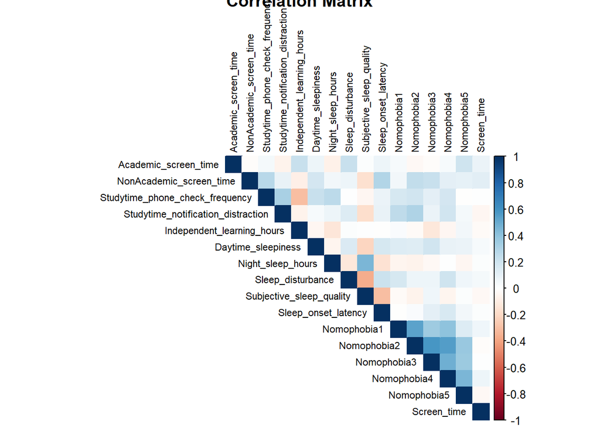

```r
# Visualize correlation matrix
corrplot(cor_matrix, method = "color", type = "upper",
         tl.cex = 0.7, tl.col = "black", title = "Correlation Matrix")
```

```r
cor(data$GPA,data$Nomophobia3)
```

```
## [1] -0.150052
```

## 3.2. Univariate Linear and Logistic Regression

```r
# Prepare ClassGPA as binary variable
classgpa_binary <- ifelse(demographic_data$ClassGPA == "Yes", 1, 0)

# Perform univariate regressions for each variable
univariate_results <- data.frame(
  Variable = character(),
  GPA_Coef = numeric(),
  GPA_Pvalue = numeric(),
  ClassGPA_OR = numeric(),
  ClassGPA_Pvalue = numeric(),
  stringsAsFactors = FALSE
)

for(i in 1:ncol(efa_data)) {
  var_name <- names(efa_data)[i]

  # Skip if variable has no variation
  if(length(unique(efa_data[[var_name]])) < 2) {
    cat("Skipping variable", var_name, ": no variation\n")
    next
  }

  # Linear regression for GPA
  lm_model <- lm(demographic_data$GPA ~ efa_data[[var_name]])
  lm_summary <- summary(lm_model)

  # Logistic regression for ClassGPA
  glm_model <- glm(classgpa_binary ~ efa_data[[var_name]], family = binomial)
  glm_summary <- summary(glm_model)

  univariate_results <- rbind(univariate_results, data.frame(
    Variable = var_name,
    GPA_Coef = lm_summary$coefficients[2, 1],
    GPA_Pvalue = lm_summary$coefficients[2, 4],
    ClassGPA_OR = exp(glm_summary$coefficients[2, 1]),
    ClassGPA_Pvalue = glm_summary$coefficients[2, 4],
    stringsAsFactors = FALSE
  ))
}

# Format results
univariate_results$GPA_Coef <- round(univariate_results$GPA_Coef, 3)
univariate_results$GPA_Pvalue <- round(univariate_results$GPA_Pvalue, 3)
univariate_results$ClassGPA_OR <- round(univariate_results$ClassGPA_OR, 3)
univariate_results$ClassGPA_Pvalue <- round(univariate_results$ClassGPA_Pvalue, 3)

# Add significance indicators
univariate_results$GPA_Sig <- ifelse(univariate_results$GPA_Pvalue < 0.001, "***",
                                    ifelse(univariate_results$GPA_Pvalue < 0.01, "**",
                                           ifelse(univariate_results$GPA_Pvalue < 0.05, "*", "")))

univariate_results$ClassGPA_Sig <- ifelse(univariate_results$ClassGPA_Pvalue < 0.001, "***",
                                         ifelse(univariate_results$ClassGPA_Pvalue < 0.01, "**",
                                                ifelse(univariate_results$ClassGPA_Pvalue < 0.05, "*", "")))

# Display results with suppressed warnings
suppressWarnings({
  kable(univariate_results, caption = "Univariate Regression Results") %>%
    kable_styling(bootstrap_options = c("striped", "hover"))
})
```

Univariate Regression Results

Variable

GPA_Coef

GPA_Pvalue

ClassGPA_OR

ClassGPA_Pvalue

GPA_Sig

ClassGPA_Sig

Academic_screen_time

-0.057

0.171

0.931

0.623

NonAcademic_screen_time

-0.057

0.234

0.932

0.674

Studytime_phone_check_frequency

-0.003

0.949

1.022

0.901

Studytime_notification_distraction

-0.025

0.562

0.845

0.269

Independent_learning_hours

0.001

0.864

1.015

0.290

Daytime_sleepiness

0.010

0.800

0.898

0.458

Night_sleep_hours

0.006

0.881

1.124

0.439

Sleep_disturbance

-0.042

0.331

0.844

0.269

Subjective_sleep_quality

-0.057

0.232

0.902

0.541

Sleep_onset_latency

-0.041

0.287

0.861

0.268

Nomophobia1

0.000

0.999

0.903

0.444

Nomophobia2

-0.038

0.357

0.880

0.376

Nomophobia3

-0.085

0.054

0.724

0.044

Nomophobia4

-0.041

0.348

0.863

0.336

Nomophobia5

-0.038

0.347

0.861

0.290

Screen_time

-0.021

0.321

0.950

0.483

# Difference of GPA across Demographics

## 1. Load Required Packages

```r
library(dplyr)
library(ggpubr)
library(ggplot2)
library(car)
library(rstatix)
library(boot)
library(tidyr)
```

## 2. Prepare the Data

```r
gpa_data <- data[, c("GPA", "Gender", "Program", "Year")] %>%
  mutate(across(c(Gender, Program, Year), as.factor))
```

## Boxplots

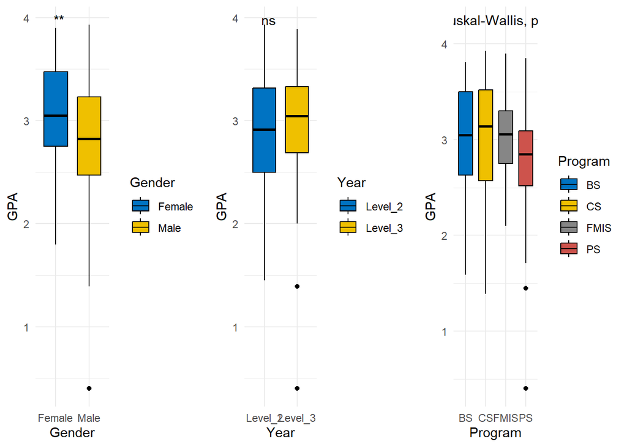

```r
p_gender <- ggboxplot(gpa_data, x = "Gender", y = "GPA", fill = "Gender", palette = "jco") +
  stat_compare_means(method = "t.test", label = "p.signif") +
  theme_minimal()

p_year <- ggboxplot(gpa_data, x = "Year", y = "GPA", fill = "Year", palette = "jco") +
  stat_compare_means(method = "t.test", label = "p.signif") +
  theme_minimal()

p_program <- ggboxplot(gpa_data, x = "Program", y = "GPA", fill = "Program", palette = "jco") +
  stat_compare_means(method = "kruskal.test", label.y = 4.2) +
  theme_minimal()

ggarrange(p_gender, p_year, p_program, ncol = 3)
```

## Assumption Checks

```r
# Shapiro-Wilk Test by Group
gpa_data %>% group_by(Gender) %>% shapiro_test(GPA)
```

```
## # A tibble: 2 × 4
##   Gender variable statistic      p
##   <fct>  <chr>        <dbl>  <dbl>
## 1 Female GPA          0.982 0.270
## 2 Male   GPA          0.962 0.0184
```

```r
gpa_data %>% group_by(Year) %>% shapiro_test(GPA)
```

```
## # A tibble: 2 × 4
##   Year    variable statistic         p
##   <fct>   <chr>        <dbl>     <dbl>
## 1 Level_2 GPA          0.980 0.208
## 2 Level_3 GPA          0.911 0.0000294
```

```r
gpa_data %>% group_by(Program) %>% shapiro_test(GPA)
```

```
## # A tibble: 4 × 4
##   Program variable statistic       p
##   <fct>   <chr>        <dbl>   <dbl>
## 1 BS      GPA          0.955 0.140
## 2 CS      GPA          0.950 0.182
## 3 FMIS    GPA          0.993 0.994
## 4 PS      GPA          0.934 0.00341
```

```r
# Levene’s Test for Homogeneity of Variance
leveneTest(GPA ~ Gender, data = gpa_data)
```

```
## Levene's Test for Homogeneity of Variance (center = median)
##        Df F value  Pr(>F)
## group   1  3.8367 0.05184 .
##       164
## ---
## Signif. codes:  0 '***' 0.001 '**' 0.01 '*' 0.05 '.' 0.1 ' ' 1
```

```r
leveneTest(GPA ~ Year, data = gpa_data)
```

```
## Levene's Test for Homogeneity of Variance (center = median)
##        Df F value Pr(>F)
## group   1  1.0333 0.3109
##       164
```

```r
leveneTest(GPA ~ Program, data = gpa_data)
```

```
## Levene's Test for Homogeneity of Variance (center = median)
##        Df F value Pr(>F)
## group   3  1.8132 0.1468
##       162
```

## Main Tests

```r
# Gender
t_gender <- t.test(GPA ~ Gender, data = gpa_data)
wilcox_gender <- wilcox.test(GPA ~ Gender, data = gpa_data)
t_gender
```

```
##
##  Welch Two Sample t-test
##
## data:  GPA by Gender
## t = 3.0452, df = 144.65, p-value = 0.002764
## alternative hypothesis: true difference in means between group Female and group Male is not equal to 0
## 95 percent confidence interval:
##  0.09306425 0.43731365
## sample estimates:
## mean in group Female   mean in group Male
##             3.065814             2.800625
```

```r
# Year
t_year <- t.test(GPA ~ Year, data = gpa_data)
wilcox_year <- wilcox.test(GPA ~ Year, data = gpa_data)
wilcox_year
```

```
##
##  Wilcoxon rank sum test with continuity correction
##
## data:  GPA by Year
## W = 3119.5, p-value = 0.2953
## alternative hypothesis: true location shift is not equal to 0
```

```r
# Program
anova_program <- kruskal.test(GPA ~ Program, data = gpa_data)
anova_program
```

```
##
##  Kruskal-Wallis rank sum test
##
## data:  GPA by Program
## Kruskal-Wallis chi-squared = 7.2095, df = 3, p-value = 0.06551
```

## Post Hoc for Program

```r
posthoc_program <- gpa_data %>%
  dunn_test(GPA ~ Program, p.adjust.method = "none") %>%
  filter(p < 0.05)

print(posthoc_program)
```

```
## # A tibble: 2 × 9
##   .y.   group1 group2    n1    n2 statistic      p  p.adj p.adj.signif
##   <chr> <chr>  <chr>  <int> <int>     <dbl>  <dbl>  <dbl> <chr>
## 1 GPA   CS     PS        29    59     -2.12 0.0339 0.0339 *
## 2 GPA   FMIS   PS        41    59     -2.16 0.0309 0.0309 *
```

## Visualize Significant Post Hoc Comparisons

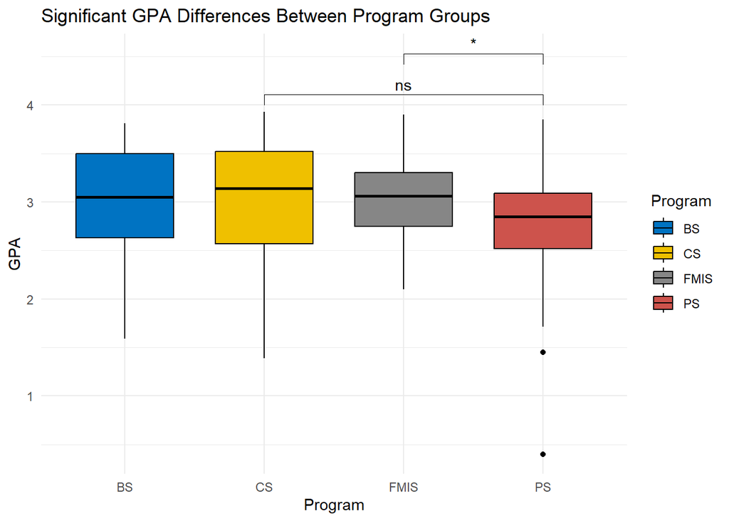

```r
# Use ggpubr with manually defined comparisons
comparisons <- list(
  c("CS", "PS"),
  c("FMIS", "PS")
)

ggboxplot(gpa_data, x = "Program", y = "GPA", fill = "Program", palette = "jco") +
  stat_compare_means(comparisons = comparisons, method = "wilcox.test", label = "p.signif") +
  theme_minimal() +
  labs(title = "Significant GPA Differences Between Program Groups")
```

## Bootstrapping

```r
set.seed(345)
boot_diff_gender <- function(data, indices) {
  d <- data[indices, ]
  mean(d$GPA[d$Gender == "Female"]) - mean(d$GPA[d$Gender == "Male"])
}

set.seed(123)
boot_gender <- boot(data = gpa_data, statistic = boot_diff_gender, R = 2000)

boot.ci(boot_gender, type = c("perc", "bca"))
```

```
## BOOTSTRAP CONFIDENCE INTERVAL CALCULATIONS
## Based on 2000 bootstrap replicates
##
## CALL :
## boot.ci(boot.out = boot_gender, type = c("perc", "bca"))
##
## Intervals :
## Level     Percentile            BCa
## 95%   ( 0.0948,  0.4346 )   ( 0.1029,  0.4447 )
## Calculations and Intervals on Original Scale
```

```r
set.seed(345)
library(boot)

# Function to bootstrap mean GPA difference between two programs
boot_program_diff <- function(data, indices, g1, g2) {
  d <- data[indices, ]  # Resample with replacement
  mean(d$GPA[d$Program == g1]) - mean(d$GPA[d$Program == g2])
}

# Define program pairs
program_pairs <- list(
  c("BS", "CS"),
  c("BS", "FMIS"),
  c("BS", "PS"),
  c("CS", "FMIS"),
  c("CS", "PS"),
  c("FMIS", "PS")
)

# Run bootstrap for each pair
set.seed(123)
boot_results <- lapply(program_pairs, function(pair) {
  boot_obj <- boot(data = gpa_data,
                   statistic = function(data, i) boot_program_diff(data, i, pair[1], pair[2]),
                   R = 2000)
  ci <- boot.ci(boot_obj, type = c("perc", "bca"))

  list(
    comparison = paste(pair[1], "vs", pair[2]),
    estimate = mean(boot_obj$t),
    perc_CI = ci$percent[4:5],
    bca_CI = ci$bca[4:5],
    pval = mean(abs(boot_obj$t) >= abs(mean(boot_obj$t)))  # approximate p-value
  )
})

boot_results
```

```
## [[1]]
## [[1]]$comparison
## [1] "BS vs CS"
##
## [[1]]$estimate
## [1] -0.05446833
##
## [[1]]$perc_CI
## [1] -0.3506757  0.2382911
##
## [[1]]$bca_CI
## [1] -0.3296271  0.2490304
##
## [[1]]$pval
## [1] 0.746
##
##
## [[2]]
## [[2]]$comparison
## [1] "BS vs FMIS"
##
## [[2]]$estimate
## [1] -0.05797928
##
## [[2]]$perc_CI
## [1] -0.2633213  0.1474341
##
## [[2]]$bca_CI
## [1] -0.2671580  0.1451844
##
## [[2]]$pval
## [1] 0.6385
##
##
## [[3]]
## [[3]]$comparison
## [1] "BS vs PS"
##
## [[3]]$estimate
## [1] 0.214502
```

[output cut: 45 more lines]

```
## [[6]]
## [[6]]$comparison
## [1] "FMIS vs PS"
##
## [[6]]$estimate
## [1] 0.2678556
##
## [[6]]$perc_CI
## [1] 0.07654147 0.46788992
##
## [[6]]$bca_CI
## [1] 0.08232955 0.47519256
##
## [[6]]$pval
## [1] 0.488
```

```r
boot_table <- do.call(rbind, lapply(boot_results, as.data.frame))
print(boot_table)
```

```
##    comparison     estimate     perc_CI      bca_CI   pval
## 1    BS vs CS -0.054468331 -0.35067568 -0.32962711 0.7460
## 2    BS vs CS -0.054468331  0.23829106  0.24903043 0.7460
## 3  BS vs FMIS -0.057979282 -0.26332128 -0.26715805 0.6385
## 4  BS vs FMIS -0.057979282  0.14743415  0.14518441 0.6385
## 5    BS vs PS  0.214501962 -0.01538707 -0.02069557 0.5030
## 6    BS vs PS  0.214501962  0.44227065  0.43592217 0.5030
## 7  CS vs FMIS  0.001648931 -0.28123436 -0.30365044 0.9905
## 8  CS vs FMIS  0.001648931  0.27770131  0.25426920 0.9905
## 9    CS vs PS  0.260424136 -0.02699213 -0.01419228 0.4950
## 10   CS vs PS  0.260424136  0.54248728  0.55070221 0.4950
## 11 FMIS vs PS  0.267855621  0.07654147  0.08232955 0.4880
## 12 FMIS vs PS  0.267855621  0.46788992  0.47519256 0.4880
```

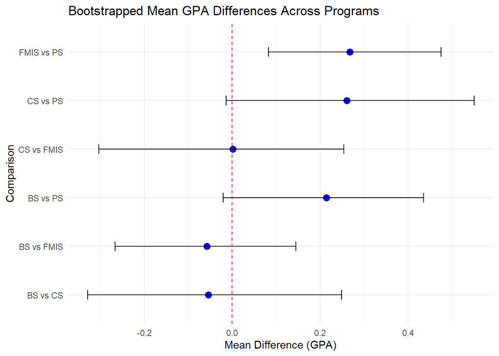

```r
library(ggplot2)

boot_df <- data.frame(
  comparison = sapply(boot_results, function(x) x$comparison),
  estimate = sapply(boot_results, function(x) x$estimate),
  lower = sapply(boot_results, function(x) x$bca_CI[1]),
  upper = sapply(boot_results, function(x) x$bca_CI[2])
)

ggplot(boot_df, aes(x = comparison, y = estimate)) +
  geom_point(size = 3, color = "blue") +
  geom_errorbar(aes(ymin = lower, ymax = upper), width = 0.2) +
  geom_hline(yintercept = 0, linetype = "dashed", color = "red") +
  coord_flip() +
  theme_minimal() +
  labs(title = "Bootstrapped Mean GPA Differences Across Programs",
       y = "Mean Difference (GPA)", x = "Comparison")
```

# 4. Exploratory Factor Analysis

```r
# Step 1: Check factorability
cat("KMO Test Results:\n")
```

```
## KMO Test Results:
```

```r
print(KMO(efa_data))
```

```
## Kaiser-Meyer-Olkin factor adequacy
## Call: KMO(r = efa_data)
## Overall MSA =  0.65
## MSA for each item =
##               Academic_screen_time            NonAcademic_screen_time
##                               0.38                               0.61
##    Studytime_phone_check_frequency Studytime_notification_distraction
##                               0.56                               0.67
##         Independent_learning_hours                 Daytime_sleepiness
##                               0.51                               0.70
##                  Night_sleep_hours                  Sleep_disturbance
##                               0.50                               0.58
##           Subjective_sleep_quality                Sleep_onset_latency
##                               0.53                               0.65
##                        Nomophobia1                        Nomophobia2
##                               0.76                               0.73
##                        Nomophobia3                        Nomophobia4
##                               0.76                               0.75
##                        Nomophobia5                        Screen_time
##                               0.69                               0.32
```

```r
cat("\nBartlett's Test of Sphericity:\n")
```

```
##
## Bartlett's Test of Sphericity:
```

```r
print(cortest.bartlett(cor(efa_data), n = nrow(efa_data)))
```

```
## $chisq
## [1] 552.0025
##
## $p.value
## [1] 1.28769e-56
##
## $df
## [1] 120
```

```r
# Step 2: Determine number of factors
cat("\nParallel Analysis:\n")
```

```
##
## Parallel Analysis:
```

```r
parallel <- fa.parallel(efa_data, fm = "minres", fa = "fa")
```

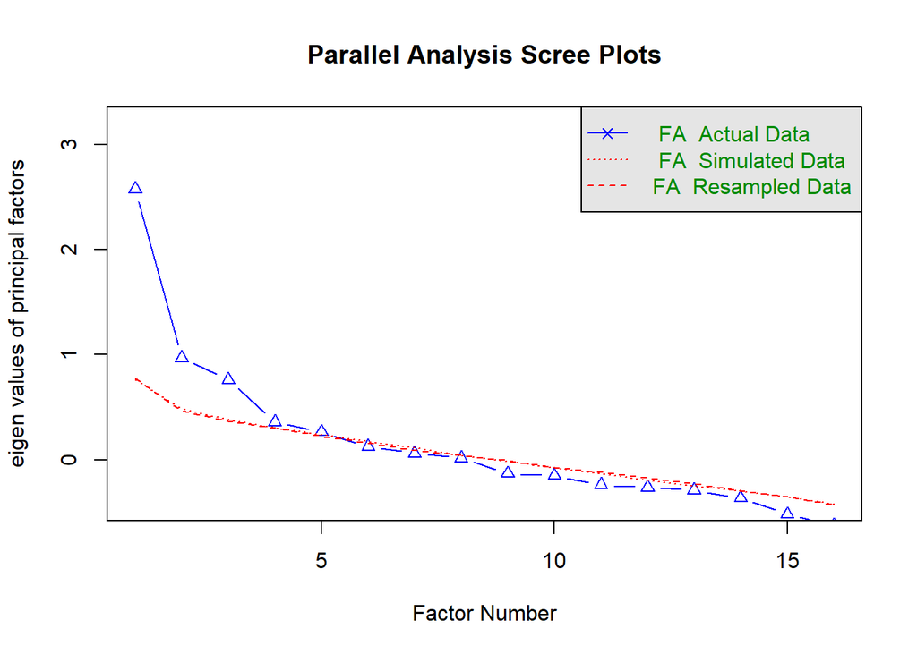

```
## Parallel analysis suggests that the number of factors =  4  and the number of components =  NA
```

```r
nfactors <- parallel$nfact
cat("Suggested number of factors:", nfactors, "\n")
```

```
## Suggested number of factors: 4
```

```r
# Step 3: Perform EFA
efa_result <- fa(efa_data, nfactors = nfactors, rotate = "oblimin", fm = "minres")
cat("\nEFA Results:\n")
```

```
##
## EFA Results:
```

```r
print(efa_result$loadings, cutoff = 0.3)
```

```
##
## Loadings:
##                                    MR1    MR2    MR4    MR3
## Academic_screen_time                                     0.998
## NonAcademic_screen_time
## Studytime_phone_check_frequency                   0.874
## Studytime_notification_distraction
## Independent_learning_hours                       -0.325
## Daytime_sleepiness
## Night_sleep_hours                          0.447  0.362
## Sleep_disturbance                         -0.381
## Subjective_sleep_quality                   0.940
## Sleep_onset_latency                       -0.379
## Nomophobia1                         0.538
## Nomophobia2                         0.842
## Nomophobia3                         0.695
## Nomophobia4                         0.711
## Nomophobia5                         0.514
## Screen_time
##
##                  MR1   MR2   MR4   MR3
## SS loadings    2.368 1.487 1.240 1.163
## Proportion Var 0.148 0.093 0.078 0.073
## Cumulative Var 0.148 0.241 0.318 0.391
```

```r
# Step 4: Check communalities
cat("\nCommunalities:\n")
```

```
##
## Communalities:
```

```r
print(efa_result$communality)
```

```
##               Academic_screen_time            NonAcademic_screen_time
##                         0.99546762                         0.16876588
##    Studytime_phone_check_frequency Studytime_notification_distraction
##                         0.77137233                         0.17282164
##         Independent_learning_hours                 Daytime_sleepiness
##                         0.15141486                         0.13183732
##                  Night_sleep_hours                  Sleep_disturbance
##                         0.33285084                         0.22351498
##           Subjective_sleep_quality                Sleep_onset_latency
##                         0.88025372                         0.17970403
##                        Nomophobia1                        Nomophobia2
##                         0.30659414                         0.71792671
##                        Nomophobia3                        Nomophobia4
##                         0.47882854                         0.52419708
##                        Nomophobia5                        Screen_time
##                         0.29418459                         0.01049332
```

```r
# Step 5: Check model fit
cat("\nFactor Analysis Fit Indices:\n")
```

```
##
## Factor Analysis Fit Indices:
```

```r
print(efa_result$fit)
```

```
## [1] 0.6856533
```

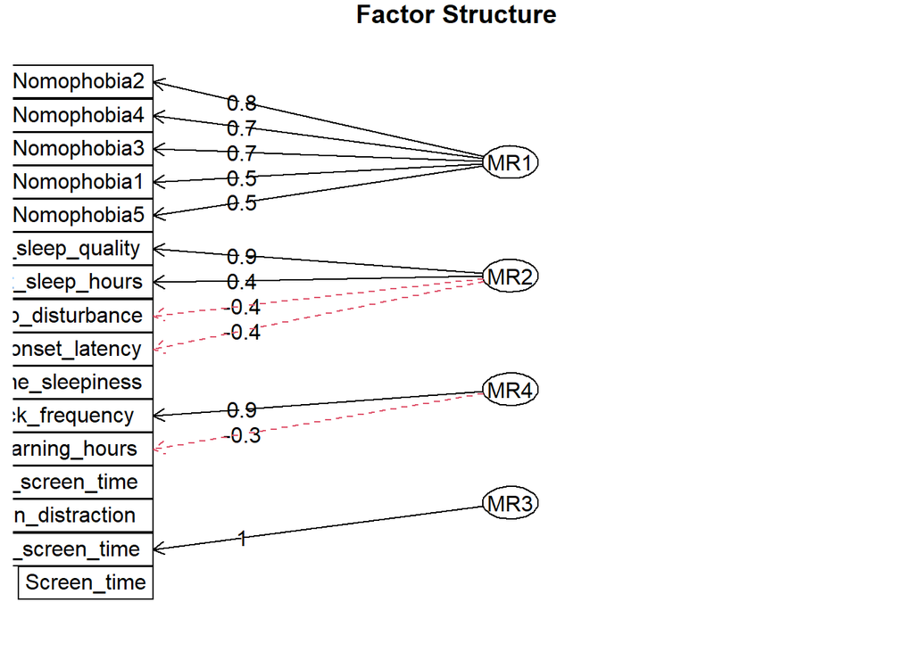

```r
# Step 6: Visualize factor structure
fa.diagram(efa_result, main = "Factor Structure")
```

# 5. Demographic Differences in Factor Scores

```r
# Extract factor scores
factor_scores <- factor.scores(efa_data, efa_result)$scores
colnames(factor_scores) <- paste0("Factor", 1:ncol(factor_scores))

# Combine with demographic data
analysis_data <- cbind(demographic_data, factor_scores)

# Convert ClassGPA to binary
analysis_data$ClassGPA_binary <- ifelse(analysis_data$ClassGPA == "Yes", 1, 0)

# Check for differences by Year
cat("Differences in factor scores by Year:\n")
```

```
## Differences in factor scores by Year:
```

```r
for(i in 1:ncol(factor_scores)) {
  factor_name <- colnames(factor_scores)[i]
  anova_result <- aov(analysis_data[[factor_name]] ~ Year, data = analysis_data)
  cat("\n", factor_name, ":\n")
  print(summary(anova_result))

  # Post-hoc test if significant
  if(summary(anova_result)[[1]]$"Pr(>F)"[1] < 0.05) {
    cat("Post-hoc Tukey test:\n")
    print(TukeyHSD(anova_result))
  }
}
```

```
##
##  Factor1 :
##              Df Sum Sq Mean Sq F value Pr(>F)
## Year          1    0.2  0.2008     0.2  0.655
## Residuals   164  164.8  1.0049
##
##  Factor2 :
##              Df Sum Sq Mean Sq F value Pr(>F)
## Year          1   1.02  1.0213   1.021  0.314
## Residuals   164 163.98  0.9999
##
##  Factor3 :
##              Df Sum Sq Mean Sq F value Pr(>F)
## Year          1   2.79  2.7881   2.819 0.0951 .
## Residuals   164 162.21  0.9891
## ---
## Signif. codes:  0 '***' 0.001 '**' 0.01 '*' 0.05 '.' 0.1 ' ' 1
##
##  Factor4 :
##              Df Sum Sq Mean Sq F value Pr(>F)
## Year          1   1.23  1.2268   1.229  0.269
## Residuals   164 163.77  0.9986
```

```r
# Check for differences by Program
cat("\nDifferences in factor scores by Program:\n")
```

```
##
## Differences in factor scores by Program:
```

```r
for(i in 1:ncol(factor_scores)) {
  factor_name <- colnames(factor_scores)[i]
  anova_result <- aov(analysis_data[[factor_name]] ~ Program, data = analysis_data)
  cat("\n", factor_name, ":\n")
  print(summary(anova_result))

  # Post-hoc test if significant
  if(summary(anova_result)[[1]]$"Pr(>F)"[1] < 0.05) {
    cat("Post-hoc Tukey test:\n")
    print(TukeyHSD(anova_result))
  }
}
```

```
##
##  Factor1 :
##              Df Sum Sq Mean Sq F value Pr(>F)
## Program       3      2  0.6668   0.663  0.576
## Residuals   162    163  1.0062
##
##  Factor2 :
##              Df Sum Sq Mean Sq F value Pr(>F)
## Program       3   1.99   0.662   0.658  0.579
## Residuals   162 163.01   1.006
##
##  Factor3 :
##              Df Sum Sq Mean Sq F value Pr(>F)
## Program       3   3.48  1.1590   1.162  0.326
## Residuals   162 161.52  0.9971
##
##  Factor4 :
##              Df Sum Sq Mean Sq F value Pr(>F)
## Program       3   1.53  0.5114   0.507  0.678
## Residuals   162 163.47  1.0090
```

```r
# Check for differences by Gender
cat("\nDifferences in factor scores by Gender:\n")
```

```
##
## Differences in factor scores by Gender:
```

```r
for(i in 1:ncol(factor_scores)) {
  factor_name <- colnames(factor_scores)[i]
  t_test <- t.test(analysis_data[[factor_name]] ~ Gender, data = analysis_data)
  cat("\n", factor_name, ":\n")
  print(t_test)
}
```

```
##
##  Factor1 :
##
##  Welch Two Sample t-test
##
## data:  analysis_data[[factor_name]] by Gender
## t = 0.48321, df = 163.98, p-value = 0.6296
## alternative hypothesis: true difference in means between group Female and group Male is not equal to 0
## 95 percent confidence interval:
##  -0.2314962  0.3815113
## sample estimates:
## mean in group Female   mean in group Male
##           0.03614823          -0.03885935
##
##
##  Factor2 :
##
##  Welch Two Sample t-test
##
## data:  analysis_data[[factor_name]] by Gender
## t = 1.9908, df = 161.83, p-value = 0.04818
## alternative hypothesis: true difference in means between group Female and group Male is not equal to 0
## 95 percent confidence interval:
##  0.002484359 0.611455723
## sample estimates:
## mean in group Female   mean in group Male
##            0.1479374           -0.1590327
##
##
##  Factor3 :
##
##  Welch Two Sample t-test
##
## data:  analysis_data[[factor_name]] by Gender
## t = -1.3267, df = 163.22, p-value = 0.1865
## alternative hypothesis: true difference in means between group Female and group Male is not equal to 0
## 95 percent confidence interval:
##  -0.50902577  0.09989551
## sample estimates:
## mean in group Female   mean in group Male
##          -0.09858561           0.10597953
##
##
##  Factor4 :
##
##  Welch Two Sample t-test
##
## data:  analysis_data[[factor_name]] by Gender
## t = 2.1997, df = 163.14, p-value = 0.02923
## alternative hypothesis: true difference in means between group Female and group Male is not equal to 0
## 95 percent confidence interval:
##  0.0345668 0.6409863
## sample estimates:
## mean in group Female   mean in group Male
##            0.1627839           -0.1749927
```

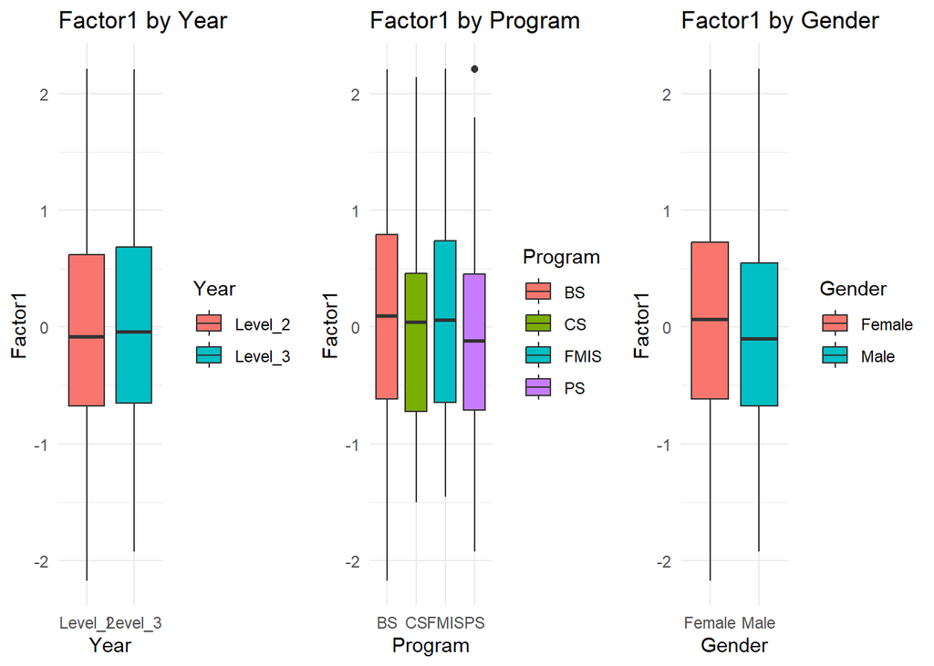

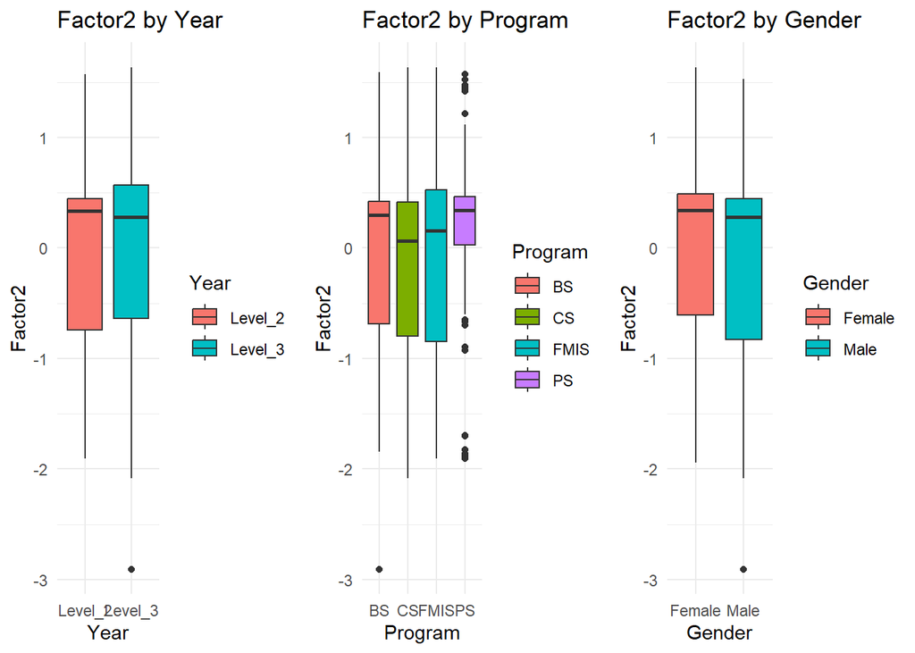

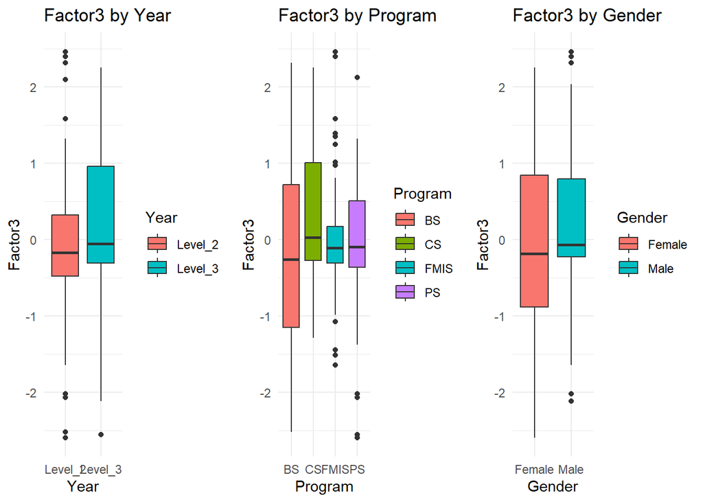

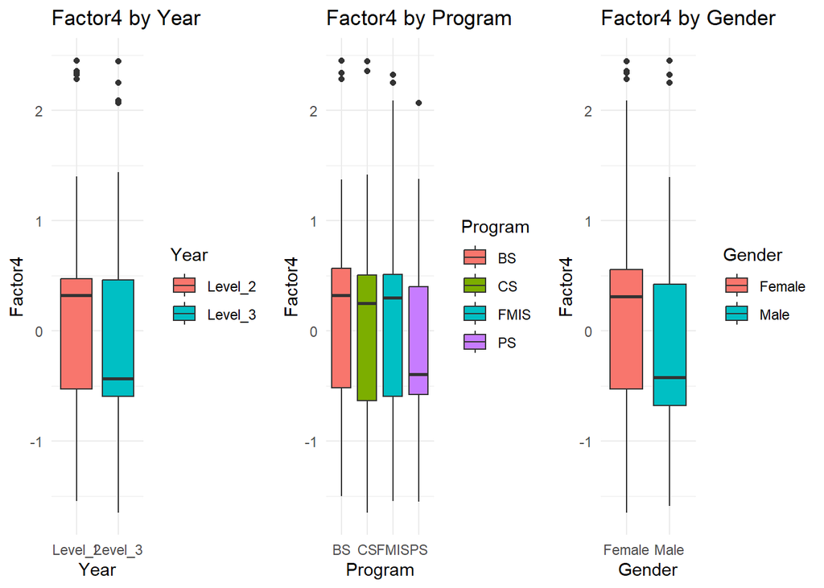

```r
# Visualize differences
for(i in 1:ncol(factor_scores)) {
  factor_name <- colnames(factor_scores)[i]

  p1 <- ggplot(analysis_data, aes(x = Year, y = .data[[factor_name]], fill = Year)) +
    geom_boxplot() +
    labs(title = paste(factor_name, "by Year")) +
    theme_minimal()

  p2 <- ggplot(analysis_data, aes(x = Program, y = .data[[factor_name]], fill = Program)) +
    geom_boxplot() +
    labs(title = paste(factor_name, "by Program")) +
    theme_minimal()

  p3 <- ggplot(analysis_data, aes(x = Gender, y = .data[[factor_name]], fill = Gender)) +
    geom_boxplot() +
    labs(title = paste(factor_name, "by Gender")) +
    theme_minimal()

  grid.arrange(p1, p2, p3, ncol = 3)
}
```

# 9. Path Analysis

```r
# Load required libraries
library(psych)
library(lavaan)
library(car)
library(MVN)
library(ggplot2)
library(reshape2)

# ================================
# STEP 1–6: EFA PROCESS
# ================================
cat("KMO Test Results:\n")
```

```
## KMO Test Results:
```

```r
print(KMO(efa_data))
```

```
## Kaiser-Meyer-Olkin factor adequacy
## Call: KMO(r = efa_data)
## Overall MSA =  0.65
## MSA for each item =
##               Academic_screen_time            NonAcademic_screen_time
##                               0.38                               0.61
##    Studytime_phone_check_frequency Studytime_notification_distraction
##                               0.56                               0.67
##         Independent_learning_hours                 Daytime_sleepiness
##                               0.51                               0.70
##                  Night_sleep_hours                  Sleep_disturbance
##                               0.50                               0.58
##           Subjective_sleep_quality                Sleep_onset_latency
##                               0.53                               0.65
##                        Nomophobia1                        Nomophobia2
##                               0.76                               0.73
##                        Nomophobia3                        Nomophobia4
##                               0.76                               0.75
##                        Nomophobia5                        Screen_time
##                               0.69                               0.32
```

```r
cat("\nBartlett's Test of Sphericity:\n")
```

```
##
## Bartlett's Test of Sphericity:
```

```r
print(cortest.bartlett(cor(efa_data), n = nrow(efa_data)))
```

```
## $chisq
## [1] 552.0025
##
## $p.value
## [1] 1.28769e-56
##
## $df
## [1] 120
```

```r
cat("\nParallel Analysis:\n")
```

```
##
## Parallel Analysis:
```

```r
parallel <- fa.parallel(efa_data, fm = "minres", fa = "fa")
```

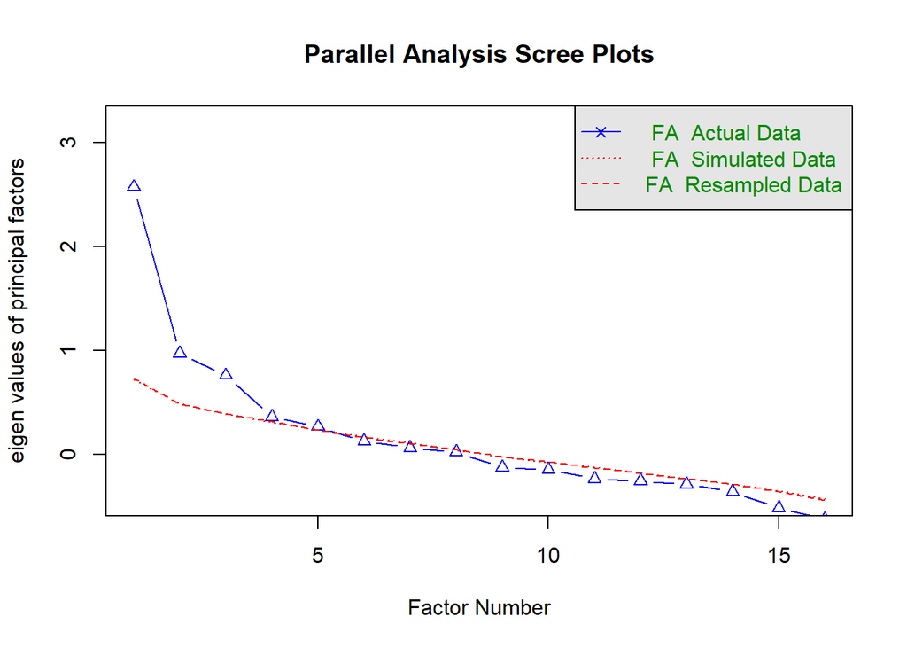

```
## Parallel analysis suggests that the number of factors =  4  and the number of components =  NA
```

```r
nfactors <- 3
cat("Suggested number of factors:",nfactors , "\n")
```

```
## Suggested number of factors: 3
```

```r
efa_result <- fa(efa_data, nfactors = nfactors, rotate = "oblimin", fm = "minres")
cat("\nEFA Results:\n")
```

```
##
## EFA Results:
```

```r
print(efa_result$loadings, cutoff = 0.3)
```

```
##
## Loadings:
##                                    MR1    MR2    MR3
## Academic_screen_time
## NonAcademic_screen_time                           0.302
## Studytime_phone_check_frequency                   0.769
## Studytime_notification_distraction                0.308
## Independent_learning_hours                       -0.386
## Daytime_sleepiness
## Night_sleep_hours                         -0.456  0.380
## Sleep_disturbance                          0.421
## Subjective_sleep_quality                  -0.862
## Sleep_onset_latency                        0.412
## Nomophobia1                         0.540
## Nomophobia2                         0.812
## Nomophobia3                         0.687
## Nomophobia4                         0.725
## Nomophobia5                         0.547
## Screen_time
##
##                  MR1   MR2   MR3
## SS loadings    2.374 1.442 1.178
## Proportion Var 0.148 0.090 0.074
## Cumulative Var 0.148 0.238 0.312
```

```r
cat("\nCommunalities:\n")
```

```
##
## Communalities:
```

```r
print(efa_result$communality)
```

```
##               Academic_screen_time            NonAcademic_screen_time
##                        0.037492381                        0.180920805
##    Studytime_phone_check_frequency Studytime_notification_distraction
##                        0.609664356                        0.176159838
##         Independent_learning_hours                 Daytime_sleepiness
##                        0.144579856                        0.132158105
##                  Night_sleep_hours                  Sleep_disturbance
##                        0.349427303                        0.211326261
##           Subjective_sleep_quality                Sleep_onset_latency
##                        0.737084157                        0.195006732
##                        Nomophobia1                        Nomophobia2
##                        0.307793083                        0.678771181
##                        Nomophobia3                        Nomophobia4
##                        0.470865493                        0.533426934
##                        Nomophobia5                        Screen_time
##                        0.285305295                        0.004779404
```

```r
cat("\nFactor Analysis Fit Indices:\n")
```

```
##
## Factor Analysis Fit Indices:
```

```r
print(efa_result$fit)
```

```
## [1] 0.6294944
```

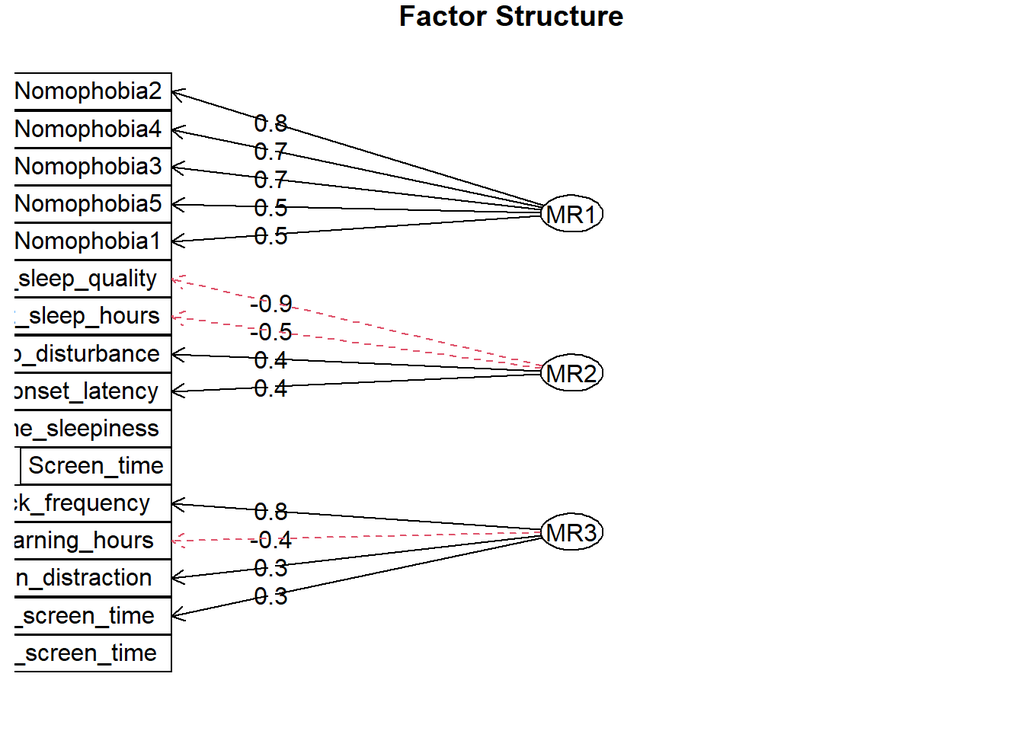

```r
fa.diagram(efa_result, main = "Factor Structure")
```

```r
# ================================
# STEP 7: Generate Factor Scores
# ================================
# Select only well-loading items per factor
selected_items <- c("Nomophobia1", "Nomophobia2", "Nomophobia3", "Nomophobia4", "Nomophobia5",
                    "Subjective_sleep_quality", "Sleep_disturbance", "Sleep_onset_latency", "Night_sleep_hours",
                    "Studytime_phone_check_frequency", "Studytime_notification_distraction", "Independent_learning_hours")

efa_data_filtered <- efa_data[, selected_items]

# Rerun EFA on only selected items
efa_result <- fa(efa_data_filtered, nfactors = 3, rotate = "oblimin", fm = "minres")

# Recompute factor scores from filtered model
factor_scores <- factor.scores(efa_data_filtered, efa_result, method = "regression")$scores

# ================================
# STEP 8: Data Preparation
# ================================
path_data <- cbind(factor_scores, demographic_data[, c("GPA", "Year", "Program", "Gender")])
path_data$ClassGPA_binary <- ifelse(path_data$GPA >= 3.0, 1, 0)

path_data$Year <- as.numeric(as.factor(path_data$Year)) - 1
path_data$Gender <- as.numeric(as.factor(path_data$Gender)) - 1
path_data$Program <- as.factor(path_data$Program)
program_dummies <- model.matrix(~ Program - 1, data = path_data)[, -1]
colnames(program_dummies) <- paste0("Program_", levels(path_data$Program)[-1])
path_data <- cbind(path_data, program_dummies)

# ================================
# STEP 9: PATH ANALYSIS (GPA)
# ================================
predictors <- c(colnames(factor_scores), "Year", "Gender", colnames(program_dummies))
path_model_gpa <- paste0("GPA ~ ", paste(predictors, collapse = " + "))

fit_gpa <- sem(path_model_gpa, data = path_data)
summary(fit_gpa, fit.measures = TRUE, standardized = TRUE, rsquare = TRUE)
```

```
## lavaan 0.6-19 ended normally after 1 iteration
##
##   Estimator                                         ML
##   Optimization method                           NLMINB
##   Number of model parameters                         9
##
##   Number of observations                           166
##
## Model Test User Model:
##
##   Test statistic                                 0.000
##   Degrees of freedom                                 0
##
## Model Test Baseline Model:
##
##   Test statistic                                24.090
##   Degrees of freedom                                 8
##   P-value                                        0.002
##
## User Model versus Baseline Model:
##
##   Comparative Fit Index (CFI)                    1.000
##   Tucker-Lewis Index (TLI)                       1.000
##
## Loglikelihood and Information Criteria:
##
##   Loglikelihood user model (H0)               -129.306
##   Loglikelihood unrestricted model (H1)       -129.306
##
##   Akaike (AIC)                                 276.613
##   Bayesian (BIC)                               304.621
##   Sample-size adjusted Bayesian (SABIC)        276.126
##
## Root Mean Square Error of Approximation:
##
##   RMSEA                                          0.000
##   90 Percent confidence interval - lower         0.000
##   90 Percent confidence interval - upper         0.000
##   P-value H_0: RMSEA <= 0.050                       NA
##   P-value H_0: RMSEA >= 0.080                       NA
```

[output cut: 15 more lines]

```
##     MR2              -0.069    0.044   -1.567    0.117   -0.069   -0.116
##     MR3               0.019    0.051    0.374    0.708    0.019    0.029
##     Year              0.066    0.084    0.789    0.430    0.066    0.058
##     Gender           -0.308    0.088   -3.491    0.000   -0.308   -0.271
##     Program_CS        0.152    0.135    1.128    0.259    0.152    0.102
##     Program_FMIS      0.176    0.125    1.400    0.162    0.176    0.134
##     Program_PS       -0.102    0.116   -0.878    0.380   -0.102   -0.086
##
## Variances:
##                    Estimate  Std.Err  z-value  P(>|z|)   Std.lv  Std.all
##    .GPA               0.278    0.031    9.110    0.000    0.278    0.865
##
## R-Square:
##                    Estimate
##     GPA               0.135
```

```r
# ================================
# STEP 10: PATH ANALYSIS (ClassGPA)
# ================================
path_model_classgpa <- paste0("ClassGPA_binary ~ ", paste(predictors, collapse = " + "))

fit_classgpa <- sem(path_model_classgpa, data = path_data,
                    ordered = "ClassGPA_binary", estimator = "WLSMV")
summary(fit_classgpa, fit.measures = TRUE, standardized = TRUE, rsquare = TRUE)
```

```
## lavaan 0.6-19 ended normally after 31 iterations
##
##   Estimator                                       DWLS
##   Optimization method                           NLMINB
##   Number of model parameters                         9
##
##   Number of observations                           166
##
## Model Test User Model:
##                                               Standard      Scaled
##   Test Statistic                                 0.000       0.000
##   Degrees of freedom                                 0           0
##
## Model Test Baseline Model:
##
##   Test statistic                                 0.000       0.000
##   Degrees of freedom                                 0           0
##   P-value                                           NA          NA
##   Scaling correction factor                                     NA
##
## User Model versus Baseline Model:
##
##   Comparative Fit Index (CFI)                    1.000       1.000
##   Tucker-Lewis Index (TLI)                       1.000       1.000
##
##   Robust Comparative Fit Index (CFI)                            NA
##   Robust Tucker-Lewis Index (TLI)                               NA
##
## Root Mean Square Error of Approximation:
##
##   RMSEA                                          0.000       0.000
##   90 Percent confidence interval - lower         0.000       0.000
##   90 Percent confidence interval - upper         0.000       0.000
##   P-value H_0: RMSEA <= 0.050                       NA          NA
##   P-value H_0: RMSEA >= 0.080                       NA          NA
##
##   Robust RMSEA                                                  NA
##   90 Percent confidence interval - lower                        NA
##   90 Percent confidence interval - upper                        NA
##   P-value H_0: Robust RMSEA <= 0.050                            NA
```

[output cut: 21 more lines]

```
##     Program_CS         0.132    0.327    0.403    0.687    0.132    0.046
##     Program_FMIS       0.172    0.306    0.561    0.575    0.172    0.069
##     Program_PS        -0.336    0.286   -1.173    0.241   -0.336   -0.149
##
## Thresholds:
##                    Estimate  Std.Err  z-value  P(>|z|)   Std.lv  Std.all
##     ClssGPA_bnry|1   -0.147    0.237   -0.621    0.534   -0.147   -0.136
##
## Variances:
##                    Estimate  Std.Err  z-value  P(>|z|)   Std.lv  Std.all
##    .ClassGPA_binry    1.000                               1.000    0.854
##
## R-Square:
##                    Estimate
##     ClassGPA_binry    0.146
```

```r
# ================================
# STEP 11: Assumption Checks
# ================================
cat("\nMultivariate Normality:\n")
```

```
##
## Multivariate Normality:
```

```r
mvn_res <- mvn(path_data[, colnames(factor_scores)], mvnTest = "hz")
print(mvn_res$multivariateNormality)
```

```
##            Test       HZ      p value MVN
## 1 Henze-Zirkler 1.438967 0.0002377648  NO
```

```r
cat("\nMulticollinearity (VIF):\n")
```

```
##
## Multicollinearity (VIF):
```

```r
vif_model <- lm(GPA ~ ., data = path_data[, c("GPA", predictors)])
print(vif(vif_model))
```

```
##          MR1          MR2          MR3         Year       Gender   Program_CS
##     1.104216     1.057712     1.131128     1.046514     1.159507     1.570837
## Program_FMIS   Program_PS
##     1.745854     1.850856
```

```r
cat("\nOutlier Detection:\n")
```

```
##
## Outlier Detection:
```

```r
mahal <- mahalanobis(path_data[, colnames(factor_scores)],
                     colMeans(path_data[, colnames(factor_scores)]),
                     cov(path_data[, colnames(factor_scores)]))
outliers <- which(pchisq(mahal, df = nfactors) > 0.999)
cat("Potential multivariate outliers (p > 0.999):", length(outliers), "\n")
```

```
## Potential multivariate outliers (p > 0.999): 0
```

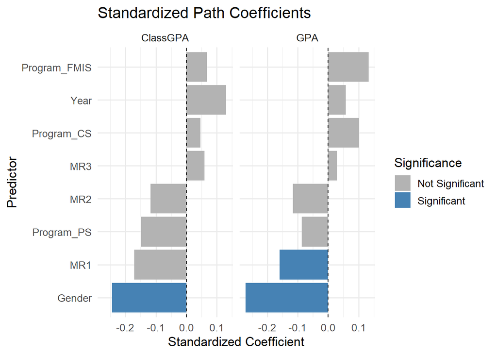

```r
# ================================
# STEP 12: Visualization of Coefficients
# ================================
get_coefs_plot <- function(fit, model_name) {
  std <- standardizedSolution(fit)
  std <- std[std$op == "~", c("lhs", "rhs", "est.std", "pvalue")]
  colnames(std) <- c("Outcome", "Predictor", "Std_Coefficient", "P_Value")
  std$Model <- model_name
  std$Significance <- ifelse(std$P_Value < 0.05, "Significant", "Not Significant")
  return(std)
}

coef_gpa <- get_coefs_plot(fit_gpa, "GPA")
coef_classgpa <- get_coefs_plot(fit_classgpa, "ClassGPA")

coef_all <- rbind(coef_gpa, coef_classgpa)

ggplot(coef_all, aes(x = reorder(Predictor, Std_Coefficient), y = Std_Coefficient,
                     fill = Significance)) +
  geom_bar(stat = "identity") +
  facet_wrap(~Model) +
  coord_flip() +
  geom_hline(yintercept = 0, linetype = "dashed") +
  labs(title = "Standardized Path Coefficients", x = "Predictor", y = "Standardized Coefficient") +
  scale_fill_manual(values = c("Significant" = "steelblue", "Not Significant" = "gray70")) +
  theme_minimal(base_size = 13)
```

```r
# ================================
# STEP 13: Save or Export (Optional)
# ================================
# saveRDS(fit_gpa, "fit_path_gpa.rds")
# saveRDS(fit_classgpa, "fit_path_classgpa.rds")
```

## Nomophobia

```r
# Extract the loadings matrix as a data frame
loadings_matrix <- as.data.frame(efa_result$loadings[1:ncol(efa_data_filtered), ])

# View only items with absolute loading ≥ 0.30 on MR1
mr1_items <- loadings_matrix[abs(loadings_matrix$MR1) >= 0.30, "MR1", drop = FALSE]

# Sort items by absolute loading strength
mr1_items <- mr1_items[order(-abs(mr1_items$MR1)), , drop = FALSE]

# Add item names
mr1_items$Item <- rownames(mr1_items)
colnames(mr1_items)[1] <- "Loading_MR1"

# Reorder columns for display
mr1_items <- mr1_items[, c("Item", "Loading_MR1")]

# Display results
cat("Items loading on MR1 (Factor 1):\n")
```

```
## Items loading on MR1 (Factor 1):
```

```r
print(mr1_items, row.names = FALSE)
```

```
##         Item Loading_MR1
##  Nomophobia2   0.8148642
##  Nomophobia4   0.7304327
##  Nomophobia3   0.6923399
##  Nomophobia1   0.5359216
##  Nomophobia5   0.5302092
```

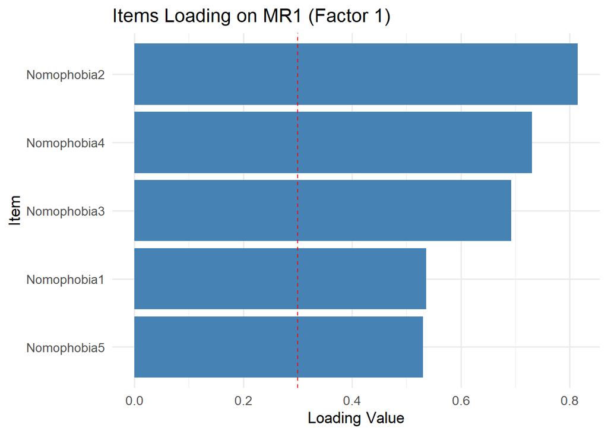

```r
library(ggplot2)

ggplot(mr1_items, aes(x = reorder(Item, Loading_MR1), y = Loading_MR1)) +
  geom_bar(stat = "identity", fill = "steelblue") +
  coord_flip() +
  geom_hline(yintercept = 0.3, linetype = "dashed", color = "red") +
  labs(title = "Items Loading on MR1 (Factor 1)",
       x = "Item", y = "Loading Value") +
  theme_minimal(base_size = 13)
```

## MLR Path Analysis

```r
# ================================
# STEP 9: PATH ANALYSIS (GPA) - Using MLR
# ================================
predictors <- c(colnames(factor_scores), "Year", "Gender", colnames(program_dummies))
path_model_gpa <- paste0("GPA ~ ", paste(predictors, collapse = " + "))

fit_gpa <- sem(path_model_gpa,
               data = path_data,
               estimator = "MLR")  # Use robust maximum likelihood

summary(fit_gpa, fit.measures = TRUE, standardized = TRUE, rsquare = TRUE)
```

```
## lavaan 0.6-19 ended normally after 1 iteration
##
##   Estimator                                         ML
##   Optimization method                           NLMINB
##   Number of model parameters                         9
##
##   Number of observations                           166
##
## Model Test User Model:
##                                               Standard      Scaled
##   Test Statistic                                 0.000       0.000
##   Degrees of freedom                                 0           0
##
## Model Test Baseline Model:
##
##   Test statistic                                24.090      24.805
##   Degrees of freedom                                 8           8
##   P-value                                        0.002       0.002
##   Scaling correction factor                                  0.971
##
## User Model versus Baseline Model:
##
##   Comparative Fit Index (CFI)                    1.000       1.000
##   Tucker-Lewis Index (TLI)                       1.000       1.000
##
##   Robust Comparative Fit Index (CFI)                            NA
##   Robust Tucker-Lewis Index (TLI)                               NA
##
## Loglikelihood and Information Criteria:
##
##   Loglikelihood user model (H0)               -129.306    -129.306
##   Loglikelihood unrestricted model (H1)       -129.306    -129.306
##
##   Akaike (AIC)                                 276.613     276.613
##   Bayesian (BIC)                               304.621     304.621
##   Sample-size adjusted Bayesian (SABIC)        276.126     276.126
##
## Root Mean Square Error of Approximation:
##
##   RMSEA                                          0.000          NA
```

[output cut: 25 more lines]

```
##     MR2              -0.069    0.042   -1.649    0.099   -0.069   -0.116
##     MR3               0.019    0.052    0.368    0.713    0.019    0.029
##     Year              0.066    0.087    0.757    0.449    0.066    0.058
##     Gender           -0.308    0.088   -3.489    0.000   -0.308   -0.271
##     Program_CS        0.152    0.142    1.076    0.282    0.152    0.102
##     Program_FMIS      0.176    0.111    1.588    0.112    0.176    0.134
##     Program_PS       -0.102    0.111   -0.924    0.356   -0.102   -0.086
##
## Variances:
##                    Estimate  Std.Err  z-value  P(>|z|)   Std.lv  Std.all
##    .GPA               0.278    0.039    7.201    0.000    0.278    0.865
##
## R-Square:
##                    Estimate
##     GPA               0.135
```

```r
# ================================
# STEP 10: PATH ANALYSIS (ClassGPA) - Using WLSMV for categorical outcome
# ================================
path_model_classgpa <- paste0("ClassGPA_binary ~ ", paste(predictors, collapse = " + "))

fit_classgpa <- sem(path_model_classgpa,
                    data = path_data,
                    ordered = "ClassGPA_binary",
                    estimator = "WLSMV")  # For categorical DV

summary(fit_classgpa, fit.measures = TRUE, standardized = TRUE, rsquare = TRUE)
```

```
## lavaan 0.6-19 ended normally after 31 iterations
##
##   Estimator                                       DWLS
##   Optimization method                           NLMINB
##   Number of model parameters                         9
##
##   Number of observations                           166
##
## Model Test User Model:
##                                               Standard      Scaled
##   Test Statistic                                 0.000       0.000
##   Degrees of freedom                                 0           0
##
## Model Test Baseline Model:
##
##   Test statistic                                 0.000       0.000
##   Degrees of freedom                                 0           0
##   P-value                                           NA          NA
##   Scaling correction factor                                     NA
##
## User Model versus Baseline Model:
##
##   Comparative Fit Index (CFI)                    1.000       1.000
##   Tucker-Lewis Index (TLI)                       1.000       1.000
##
##   Robust Comparative Fit Index (CFI)                            NA
##   Robust Tucker-Lewis Index (TLI)                               NA
##
## Root Mean Square Error of Approximation:
##
##   RMSEA                                          0.000       0.000
##   90 Percent confidence interval - lower         0.000       0.000
##   90 Percent confidence interval - upper         0.000       0.000
##   P-value H_0: RMSEA <= 0.050                       NA          NA
##   P-value H_0: RMSEA >= 0.080                       NA          NA
##
##   Robust RMSEA                                                  NA
##   90 Percent confidence interval - lower                        NA
##   90 Percent confidence interval - upper                        NA
##   P-value H_0: Robust RMSEA <= 0.050                            NA
```

[output cut: 21 more lines]

```
##     Program_CS         0.132    0.327    0.403    0.687    0.132    0.046
##     Program_FMIS       0.172    0.306    0.561    0.575    0.172    0.069
##     Program_PS        -0.336    0.286   -1.173    0.241   -0.336   -0.149
##
## Thresholds:
##                    Estimate  Std.Err  z-value  P(>|z|)   Std.lv  Std.all
##     ClssGPA_bnry|1   -0.147    0.237   -0.621    0.534   -0.147   -0.136
##
## Variances:
##                    Estimate  Std.Err  z-value  P(>|z|)   Std.lv  Std.all
##    .ClassGPA_binry    1.000                               1.000    0.854
##
## R-Square:
##                    Estimate
##     ClassGPA_binry    0.146
```

### Assumption Check

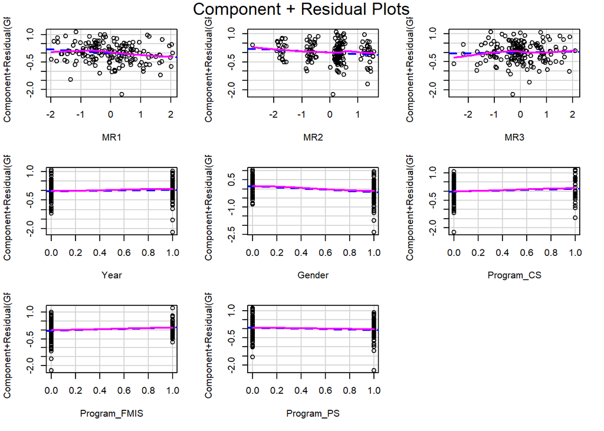

```r
library(car)

# Build a linear model for visual diagnostics
linear_model <- lm(GPA ~ ., data = path_data[, c("GPA", predictors)])

# Check linearity via Component + Residual (Partial Residual) Plots
crPlots(linear_model)
```

### Sample Size Adequacy

```r
# Count total predictors
n_parameters <- length(predictors)

# Check sample size
n_obs <- nrow(path_data)

cat("Sample size:", n_obs, "\n")
```

```
## Sample size: 166
```

```r
cat("Number of predictors:", n_parameters, "\n")
```

```
## Number of predictors: 8
```

```r
cat("Ratio (Cases per parameter):", round(n_obs / n_parameters, 2), "\n")
```

```
## Ratio (Cases per parameter): 20.75
```

```r
if ((n_obs / n_parameters) >= 10) {
  cat("✅ Sample size is adequate (≥10 cases per parameter).\n")
} else {
  cat("⚠️ Sample size may be insufficient (<10 cases per parameter).\n")
}
```

```
## ✅ Sample size is adequate (≥10 cases per parameter).
```

### Residual Diagnostics

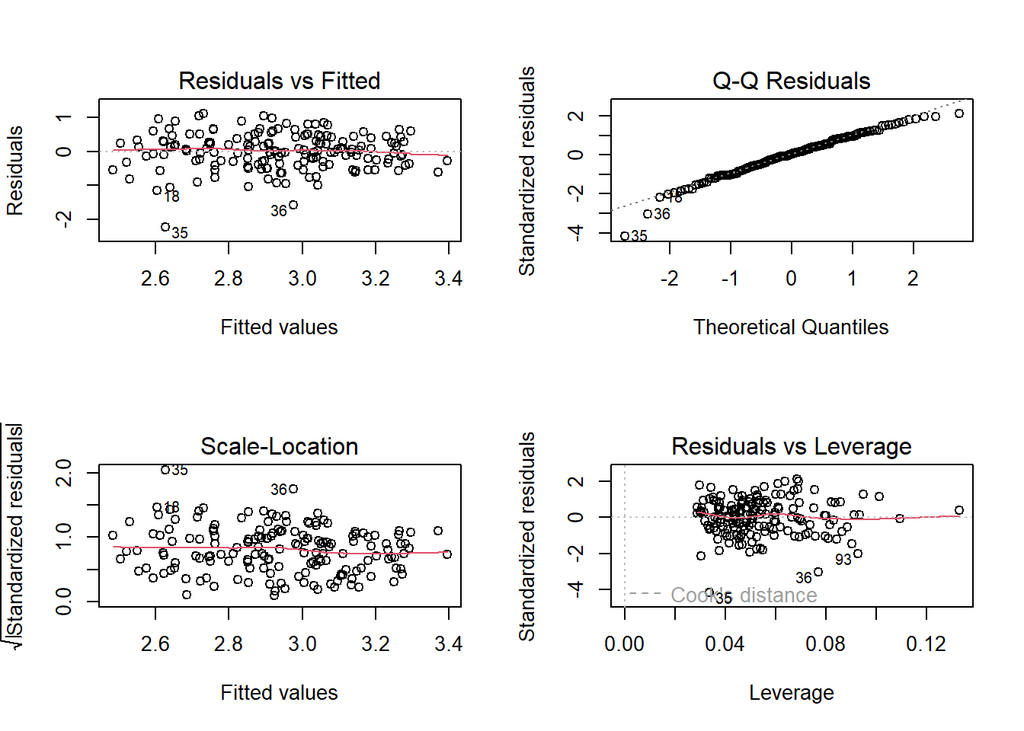

```r
# Basic residual plots
par(mfrow = c(2, 2))
plot(linear_model)
```

```
## Observations with Cook's D > 4/n: 7
```

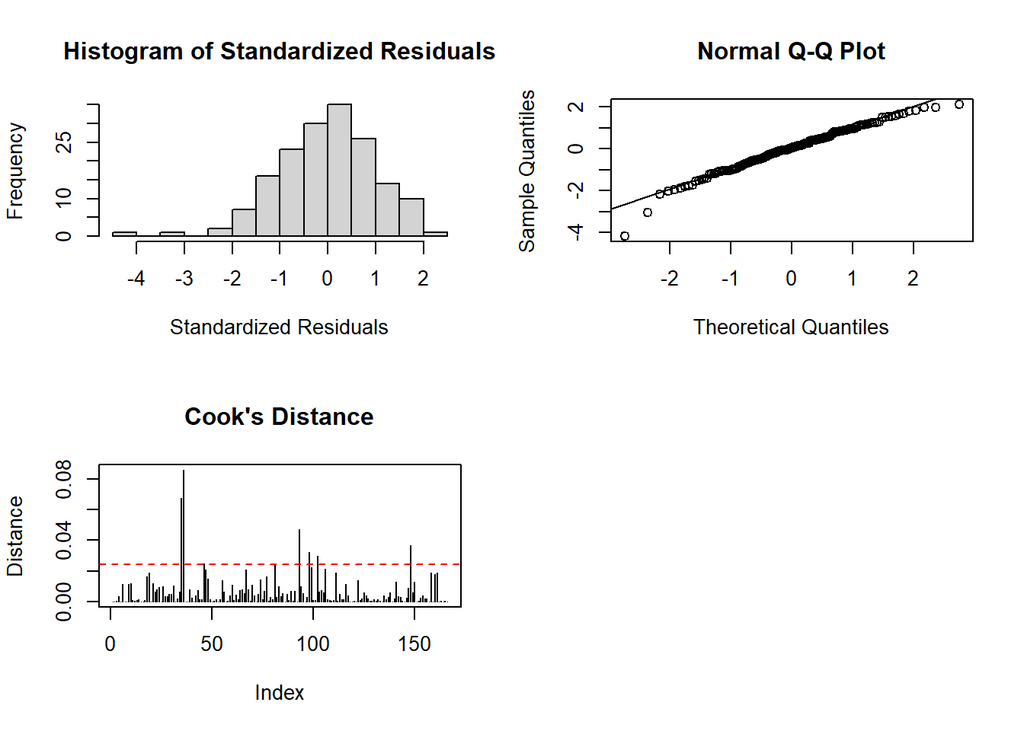

```r
# Histogram and Q-Q plot of residuals
residuals_std <- rstandard(linear_model)
hist(residuals_std, main = "Histogram of Standardized Residuals", xlab = "Standardized Residuals")
qqnorm(residuals_std); qqline(residuals_std)

# Check for influential points (Cook's distance)
cooksd <- cooks.distance(linear_model)
plot(cooksd, type = "h", main = "Cook's Distance", ylab = "Distance")
abline(h = 4 / n_obs, col = "red", lty = 2)
cat("Observations with Cook's D > 4/n:", sum(cooksd > 4 / n_obs), "\n")
```

### Multicollinearity

```r
cat("\nMulticollinearity (VIF) - Relevant for all estimators:\n")
```

```
##
## Multicollinearity (VIF) - Relevant for all estimators:
```

```r
vif_model <- lm(GPA ~ ., data = path_data[, c("GPA", predictors)])
print(vif(vif_model))
```

```
##          MR1          MR2          MR3         Year       Gender   Program_CS
##     1.104216     1.057712     1.131128     1.046514     1.159507     1.570837
## Program_FMIS   Program_PS
##     1.745854     1.850856
```

```r
# Check that no VIF > 5 or 10 (depending on threshold)
```

## Bootstrapped Path Analysis

```r
# ================================
# Load Required Libraries
# ================================
library(lavaan)
library(ggplot2)

# ================================
# Define Path Model
# ================================
predictors <- c(colnames(factor_scores), "Year", "Gender", colnames(program_dummies))
path_model_gpa <- paste0("GPA ~ ", paste(predictors, collapse = " + "))

# ================================
# Fit SEM Model with Bootstrapping
# ================================
fit_boot <- sem(path_model_gpa,
                data = path_data,
                estimator = "ML",         # Robust estimation
                se = "bootstrap",          # Use bootstrapped standard errors
                bootstrap = 5000)          # Recommended: ≥5000 resamples

# ================================
# Summary with Bootstrapped CIs
# ================================
summary(fit_boot,
        fit.measures = TRUE,
        standardized = TRUE,
        rsquare = TRUE,
        ci = TRUE)
```

```
## lavaan 0.6-19 ended normally after 1 iteration
##
##   Estimator                                         ML
##   Optimization method                           NLMINB
##   Number of model parameters                         9
##
##   Number of observations                           166
##
## Model Test User Model:
##
##   Test statistic                                 0.000
##   Degrees of freedom                                 0
##
## Model Test Baseline Model:
##
##   Test statistic                                24.090
##   Degrees of freedom                                 8
##   P-value                                        0.002
##
## User Model versus Baseline Model:
##
##   Comparative Fit Index (CFI)                    1.000
##   Tucker-Lewis Index (TLI)                       1.000
##
## Loglikelihood and Information Criteria:
##
##   Loglikelihood user model (H0)               -129.306
##   Loglikelihood unrestricted model (H1)       -129.306
##
##   Akaike (AIC)                                 276.613
##   Bayesian (BIC)                               304.621
##   Sample-size adjusted Bayesian (SABIC)        276.126
##
## Root Mean Square Error of Approximation:
##
##   RMSEA                                          0.000
##   90 Percent confidence interval - lower         0.000
##   90 Percent confidence interval - upper         0.000
##   P-value H_0: RMSEA <= 0.050                       NA
##   P-value H_0: RMSEA >= 0.080                       NA
```

[output cut: 27 more lines]

```
##     0.066    0.058
##    -0.308   -0.271
##     0.152    0.102
##     0.176    0.134
##    -0.102   -0.086
##
## Variances:
##                    Estimate  Std.Err  z-value  P(>|z|) ci.lower ci.upper
##    .GPA               0.278    0.038    7.254    0.000    0.195    0.342
##    Std.lv  Std.all
##     0.278    0.865
##
## R-Square:
##                    Estimate
##     GPA               0.135
```

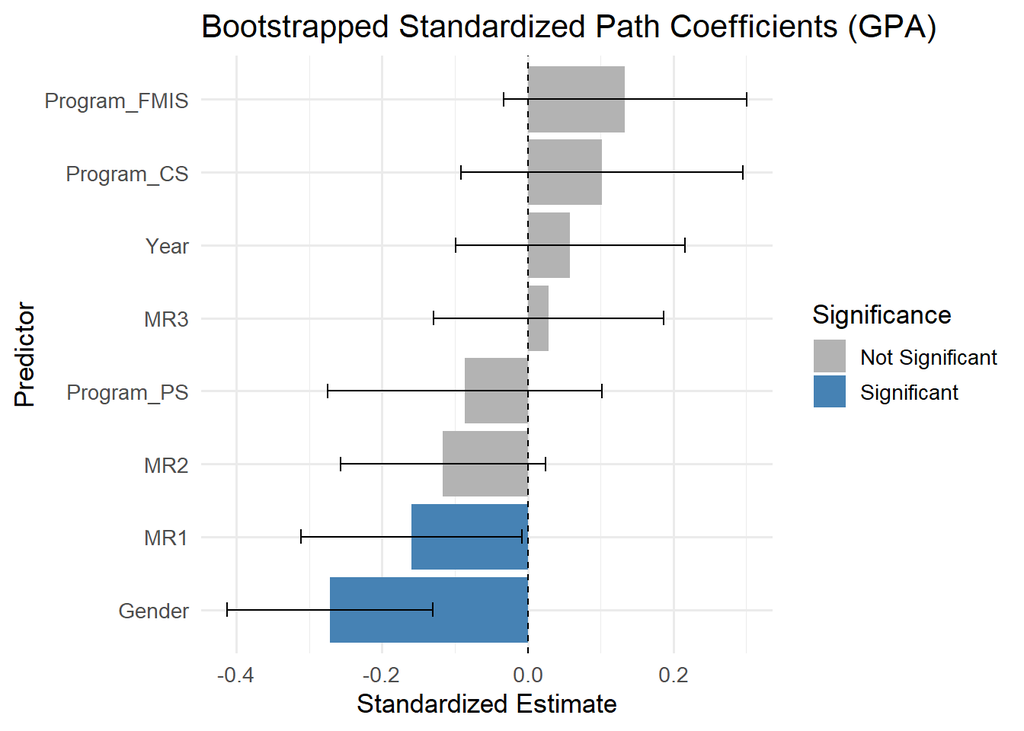

```r
# ================================
# Extract & Plot Coefficients
# ================================
get_boot_coefs_plot <- function(fit, model_name) {
  std <- standardizedSolution(fit, ci = TRUE)
  std <- std[std$op == "~", c("lhs", "rhs", "est.std", "ci.lower", "ci.upper", "pvalue")]
  colnames(std) <- c("Outcome", "Predictor", "Std_Estimate", "CI_Lower", "CI_Upper", "P_Value")
  std$Model <- model_name
  std$Significance <- ifelse(std$P_Value < 0.05, "Significant", "Not Significant")
  return(std)
}

boot_coefs <- get_boot_coefs_plot(fit_boot, "Bootstrapped GPA")

ggplot(boot_coefs, aes(x = reorder(Predictor, Std_Estimate), y = Std_Estimate,
                       fill = Significance)) +
  geom_bar(stat = "identity") +
  geom_errorbar(aes(ymin = CI_Lower, ymax = CI_Upper), width = 0.2) +
  coord_flip() +
  geom_hline(yintercept = 0, linetype = "dashed") +
  labs(title = "Bootstrapped Standardized Path Coefficients (GPA)",
       x = "Predictor", y = "Standardized Estimate") +
  scale_fill_manual(values = c("Significant" = "steelblue", "Not Significant" = "gray70")) +
  theme_minimal(base_size = 13)
```

## Mediation

```r
set.seed(123)
library(lavaan)

# Define the path analysis model with labels
path_model <- '
  # Structural regressions with labels
  MR2 ~ a1*MR1          # MR1 → MR2
  MR3 ~ a2*MR1          # MR1 → MR3
  GPA ~ c*MR1 + b1*MR2 + b2*MR3 + Year + Gender + Program_CS + Program_FMIS + Program_PS

  # Indirect effects
  ind_nomophobia_sleep := a1*b1
  ind_nomophobia_distraction := a2*b2

  # Total effect of MR1 on GPA
  total_nomophobia := c + (a1*b1) + (a2*b2)
'

# Fit the model
fit_path <- sem(path_model, data = path_data, estimator = "ML", se = "bootstrap", bootstrap = 5000)

# Get results
summary(fit_path, fit.measures = TRUE, standardized = TRUE, rsquare = TRUE, ci = TRUE)
```

```
## lavaan 0.6-19 ended normally after 1 iteration
##
##   Estimator                                         ML
##   Optimization method                           NLMINB
##   Number of model parameters                        13
##
##   Number of observations                           166
##
## Model Test User Model:
##
##   Test statistic                                15.951
##   Degrees of freedom                                11
##   P-value (Chi-square)                           0.143
##
## Model Test Baseline Model:
##
##   Test statistic                                53.701
##   Degrees of freedom                                21
##   P-value                                        0.000
##
## User Model versus Baseline Model:
##
##   Comparative Fit Index (CFI)                    0.849
##   Tucker-Lewis Index (TLI)                       0.711
##
## Loglikelihood and Information Criteria:
##
##   Loglikelihood user model (H0)               -558.209
##   Loglikelihood unrestricted model (H1)       -550.233
##
##   Akaike (AIC)                                1142.418
##   Bayesian (BIC)                              1182.874
##   Sample-size adjusted Bayesian (SABIC)       1141.715
##
## Root Mean Square Error of Approximation:
##
##   RMSEA                                          0.052
##   90 Percent confidence interval - lower         0.000
##   90 Percent confidence interval - upper         0.104
##   P-value H_0: RMSEA <= 0.050                    0.425
```

[output cut: 52 more lines]

```
## R-Square:
##                    Estimate
##     MR2               0.005
##     MR3               0.075
##     GPA               0.141
##
## Defined Parameters:
##                    Estimate  Std.Err  z-value  P(>|z|) ci.lower ci.upper
##     ind_nomphb_slp    0.005    0.009    0.539    0.590   -0.009    0.028
##     ind_nmphb_dstr    0.005    0.014    0.337    0.736   -0.024    0.035
##     total_nomophob   -0.089    0.047   -1.876    0.061   -0.183    0.005
##    Std.lv  Std.all
##     0.005    0.008
##     0.005    0.008
##    -0.089   -0.143
```

# Internal Validity

```r
# Load required package
library(psych)

# ----------------------------------------
# Step 1: Apply reverse coding (if needed)
# ----------------------------------------

efa_data_rc <- efa_data  # Copy to preserve original

# Reverse for MR2
efa_data_rc$Subjective_sleep_quality <- max(efa_data_rc$Subjective_sleep_quality, na.rm = TRUE) - efa_data_rc$Subjective_sleep_quality
efa_data_rc$Night_sleep_hours <- max(efa_data_rc$Night_sleep_hours, na.rm = TRUE) - efa_data_rc$Night_sleep_hours

# Reverse for MR3
efa_data_rc$Independent_learning_hours <- max(efa_data_rc$Independent_learning_hours, na.rm = TRUE) - efa_data_rc$Independent_learning_hours

# ----------------------------------------
# Step 2: Define item groupings
# ----------------------------------------

items_MR1 <- c("Nomophobia1", "Nomophobia2", "Nomophobia3", "Nomophobia4", "Nomophobia5")
items_MR2 <- c("Subjective_sleep_quality", "Sleep_disturbance", "Sleep_onset_latency", "Night_sleep_hours")
items_MR3 <- c("Studytime_phone_check_frequency", "Studytime_notification_distraction", "Independent_learning_hours")

factor_items <- list(MR1 = items_MR1, MR2 = items_MR2, MR3 = items_MR3)

# ----------------------------------------
# Step 3: Compute Omega
# ----------------------------------------

omega_results <- data.frame(Factor = character(), Omega_Total = numeric(), stringsAsFactors = FALSE)

for (factor in names(factor_items)) {
  items <- factor_items[[factor]]
  data_subset <- efa_data_rc[, items]

  omega_val <- omega(data_subset, nfactors = 1, plot = FALSE)$omega.tot

  omega_results <- rbind(omega_results,
                         data.frame(Factor = factor,
                                    Omega_Total = round(omega_val, 3)))
}
```

```
## Omega_h for 1 factor is not meaningful, just omega_t
```

```
## Omega_h for 1 factor is not meaningful, just omega_t
```

```
## Omega_h for 1 factor is not meaningful, just omega_t
```

```r
# ----------------------------------------
# Step 4: Output Results
# ----------------------------------------

print(omega_results)
```

```
##   Factor Omega_Total
## 1    MR1       0.795
## 2    MR2       0.638
## 3    MR3       0.587
```